# Causal Inference for Time-varying Treatments

## Time-varying Treatments

### The causal effect of time-varying treatments

Consider a time-fixed treatment variable $A$ (1: treated, 0: untreated) at time zero of follow-up and an outcome variable $Y$. The average causal effect of $A$ on the outcome $Y$ as the contrast between the mean counterfactual outcome $Y^{a=1}$ under treatment and the mean counterfactual outcome $Y^{a=0}$ under no treatment, that is,

$$E[Y^{a=1}] - E[Y^{a=0}]$$

Because treatment status is determined at a **single time** (time zero) for everybody, the average causal effect does not need to make reference to the time at which treatment occurs. In contrast, causal contrasts that involve time-varying treatments need to incorporate time explicitly.

Consider a time-varying dichotomous treatment $A_k$ that may change at every month $k$ of follow-up, where $k = 0, 1, 2, \dots, K$. $A_k$ takes value 1 if the individual receives treatment in month $k$, and 0 otherwise. No individuals received treatment before the start of the study at time 0, i.e., $A_{−1} = 0$ for all individuals. The history of treatment from time 0 to time k is denoted by

$$\bar{A}_k = (A_0, A_1, \dots, A_k)$$

An individual who receives treatment continuously throughout the follow-up has treatment history $\bar{A} = (1, 1, \dots, 1) = \bar{1}$. Analogously, an individual who never receives treatment during the follow-up has treatment history $\bar{A} = (0, 0, \dots, 0) = \bar{0}$.

Suppose $Y$ measures health status – with higher values of $Y$ indicating better health – at the end of follow-up at time $K + 1$. We would like to estimate the average causal effect of the time-varying treatment $\bar A$ on the outcome $Y$. Therefore, we will have to define the average causal effect as a contrast between the counterfactual mean outcomes under two treatment strategies that involve treatment at **all times** between the start ($k = 0$) and the end ($k = K$) of the follow-up.

### Treatment strategies

A treatment strategy – also referred to as a plan, policy, protocol, or regime – is a rule to assign treatment at each time k of follow-up.

$$\begin{aligned}
&\text{Strategy 1 - Always Treat:} & \quad \bar{a} = (1, 1, \dots, 1) = \bar{1} \\
&\text{Strategy 2 - Never Treat:} & \quad \bar{a} = (0, 0, \dots, 0) = \bar{0}
\end{aligned}$$

We can define an average causal effect of $\bar A$ on the outcome $Y$ as the contrast between the mean counterfactual outcome $Y^{\bar a = \bar 1}$ under the strategy “always treat” and the mean counterfactual outcome $Y^{\bar a = \bar 0}$ under the strategy “never treat”, that is,

$$E[Y^{\bar a = \bar 1}] - E[Y^{\bar a = \bar 0}]$$

The number of possible contrasts is very large: we can define at least $2^K$ treatment strategies. In fact, these $2^K$ such strategies **do not exhaust all possible treatment strategies**.

**Note**

- Deterministic dynamic treatment strategy

  $$g = [g_0(\bar a_{-1}, l_0), \dots, g_K(\bar a_{K-1}, \bar l_K)]$$

  where $g_k(\bar a_{K-1}, \bar l_k)$ specifies the treatment assigned at $k$ to an individual with past history $(\bar a_{K-1}, \bar l_k)$.
- Deterministic static treatment strategy

  $$g = [g_0(\bar a_{-1}), \dots, g_K(\bar a_{K-1})]$$

  where $g_k(\bar a_{K-1})$ does not depend on $\bar l_k$
- Random treatment strategies

  Random treatment strategies that do not assign a particular value of treatment, but rather a probability of receiving a treatment value. Random treatment strategies can be static or dynamic.

We refer to the strategy $g$ for which the mean counterfactual outcome $E [Y^g]$ is maximized (when higher values of outcome are better) as the **optimal treatment strategy**. Optimal strategy will almost always be dynamic. However, random strategies (i.e., randomized trials) remain scientifically necessary because, before the trial, it is unknown which deterministic strategy is optimal.

### Sequentially randomized experiments

- Notations in causal diagrams
  - $A_k$: time-varying treatment
  - $L_k$: set of measured variables
  - $Y$: outcome
  - $U_k$: set of unmeasured variables that are common causes of at least two other variables on the causal graph

**Causal graph 1**

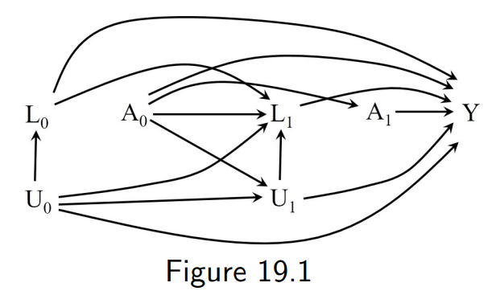

The causal diagram in Figure 19.1 lacks arrows from either the measured covariates $\bar L_k$ or the unmeasured covariates $\bar U_k$ into treatment $A_k$. It could represent a randomized experiment in which treatment $A_k$ at each time $k$ is randomly assigned with a probability that depends **only on prior treatment history**.

When interested in the contrast of static treatment strategies, Figure 19.1 is the proper generalization of no confounding by measured or unmeasured variables for time-varying treatments.

**Causal graph 2**

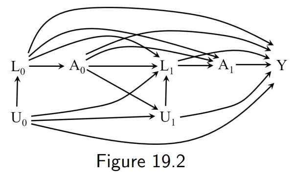

The causal diagram in Figure 19.2 includes arrows from measured covariates $\bar L_k$, but not from the unmeasured covariates $\bar U_k$, into treatment $A_k$. It could represent a randomized experiment in which treatment $A_k$ at each time $k$ is randomly assigned by the investigators with a probability that depends on **prior treatment and measured covariate history**.

An experiment in which treatment is randomly assigned at each time $k$ to each individual is referred to as a sequentially randomized experiment. Therefore Figures 19.1 and 19.2 could represent sequentially randomized experiments.

**Causal graph 3**

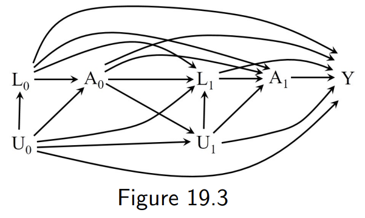

The causal diagram in Figure 19.3 includes arrows from both measured covariates $\bar L_k$ and unmeasured covariates $\bar U_k$ into treatment $A_k$. In contrast to Figures 19.1 and 19.2, Figure 19.3 cannot represent a randomized experiment: the value of treatment $A_k$ at each time $k$ depends partly on unmeasured variables $U$ which are causes of $L_k$ and $Y$ , but unmeasured variables obviously cannot be used by investigators to assign treatment.

In observational studies, decisions about treatment often depend on outcome predictors such as prognostic factors. Therefore, observational studies will be typically represented by either Figure 19.2 or Figure 19.3 rather than Figure 19.1. An observational study represented by Figure 19.2 would differ from a sequentially randomized experiment only in that **the assignment probabilities are unknown** (but could be estimated from the data).

Unfortunately, it is impossible to show empirically whether an observational study is represented by the causal diagram in either Figure 19.2 or Figure 19.3.

### Sequential exchangeability

**Note**

- Exchangeability

  Exchangeability means that the outcome under the potential treatment value among the treated, $Pr(Y^a = 1 | A = 1)$, equals the outcome under the potential treatment value a among the untreated, $Pr(Y^a = 1 | A = 0)$, for both $a = 0$ and $a = 1$. In other words, counterfactual outcome and the actual treatment are independent, $Y^a \perp\!\!\!\perp A$ for all values $a$.

Causal inference with time-varying treatments requires adjusting for the time-varying covariates $\bar L_k$ to achieve conditional exchangeability at each time point, i.e., sequential conditional exchangeability.

$$Y^g \perp\!\!\!\perp A_k \ | \ \bar A_{k-1} = g(\bar A_{k-2}, \bar L_{k-1}), \bar L_k \qquad \text{for all strategies } g, \quad k = 0, 1, \dots, K$$

A sequentially randomized experiment implies sequential exchangeability for $Y^g$

In addition to some form of sequential exchangeability, causal inference involving time-varying treatments also requires a sequential version of the conditions of positivity and consistency.

**Note**

- Positivity condition

  The positivity condition needs to be generalized from the fixed version “if $f_L(l) \neq 0, f_{A|L}(a|l) > 0$ for all $a$ and $l$” to the sequential version

$$\text{If } f_{\bar A_{k-1}, \bar L_k}(\bar a_{k-1}, \bar l_k) \neq 0, \text{ then } f_{A_k | \bar A_{k-1}, \bar L_k}(a_k | \bar a_{k-1}, \bar l_k) > 0 \quad \text{for all } (\bar a_k, \bar l_k)$$

- Consistency condition

  The consistency condition needs to be generalized from the fixed version “if $A = a$, for a given individual, then $Y^a = Y$” for that individual” to the sequential version

$$Y^{\bar a} = Y^{\bar a^*} \ \text{ if } \ \bar a^* = \bar a; \quad Y^{\bar a} = Y \ \text{ if } \ \bar A = \bar a; \quad \bar L_k^{\bar a} = \bar L_k^{\bar a^*} \ \text{ if } \ \bar a^*_{k-1} = \bar a_{k-1}; \quad \bar L_k^{\bar a} = \bar L_k \ \text{ if } \ \bar A_{k-1} = \bar a_{k-1}$$

### Confounding

#### The structure of confounding

In observational studies treatment may be determined by many factors. If those factors affect the risk of developing the outcome then the effects of those factors become entangled with the effect of treatment. We then say that there is confounding, which is just a form of **lack of exchangeability between the treated and the untreated**. Confounding is often viewed as the main shortcoming of observational studies.

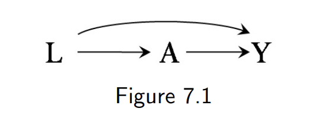

The diagram in Figure 7.1 depicts a treatment $A$, an outcome $Y$, and their shared (or common) cause $L$. In a causal diagram, a **backdoor path** is a noncausal path between treatment and outcome that remains even if all arrows pointing from treatment to other variables are removed. That is, the path has an arrow pointing into treatment.

We refer to the bias caused by shared causes of treatment and outcome as confounding. Because of confounding, association is not causation.

#### Confounding and exchangeability

When exchangeability $Y^a \perp\!\!\!\perp A$ holds, the average causal effect can be identified without adjustment for any variables. For a binary treatment A, the average causal effect $E[Y^{a=1}] - E[Y^{a=0}]$ is calculated as the difference of conditional means $E[Y | A=1] - E[Y | A=0]$.

When exchangeability $Y^a \perp\!\!\!\perp A$ does not hold but conditional exchangeability $Y^a \perp\!\!\!\perp A | L$ does, the average causal effect can also be identified with adjustment for the variables $L$.

In practice, if we believe confounding is likely, a key question arises: can we determine whether there exists a set of measured covariates $L$ for which conditional exchangeability holds? Answering this question is possible **if one knows the causal DAG that generated the data**. There are two main approaches: (i) the backdoor criterion applied to the causal DAG, and (ii) the transformation of the causal DAG into a SWIG.

**Note**

- Backdoor criterion

  A set of coviariates $L$ satisfies the backdoor criterion if all backdoor paths between $A$ and $Y$ are blocked by conditioning on $L$ and $L$ contains no variables that are descendants of treatment $A$. Conditional exchangeability $Y^a \perp\!\!\!\perp A |L$ holds if and only if $L$ satisfies the backdoor criterion.

  The backdoor criterion does not answer questions regarding the magnitude or direction of confounding. It is important to consider the expected direction and magnitude of the bias.